# Reproducible Research Peer Grade Assessment Project 1

## Imputing missing values

### Calculating and reporting the total number of missing values in the dataset (i.e. the total number of rows with NAs)

```r
sum(is.na(Acts))
```

```
## [1] 2304
```

As per dataset being considered total number rows with missing value is 2304.

### Missing values are being replaced by mean values for that days

```r
acts_noNA <- Acts

acts_noNA$day_name <- weekdays(as.POSIXlt(Acts$date), abbreviate = FALSE)

for (i in 1:nrow(acts_noNA)) {
    if(is.na(acts_noNA[i, ]$steps)) {
        acts_noNA[i, ]$steps <-mean(acts_noNA[acts_noNA$day_name == acts_noNA[i, ]$day_name,]$steps, na.rm = TRUE)
    }
}
```

### Creating histogram of the total number of steps taken each day

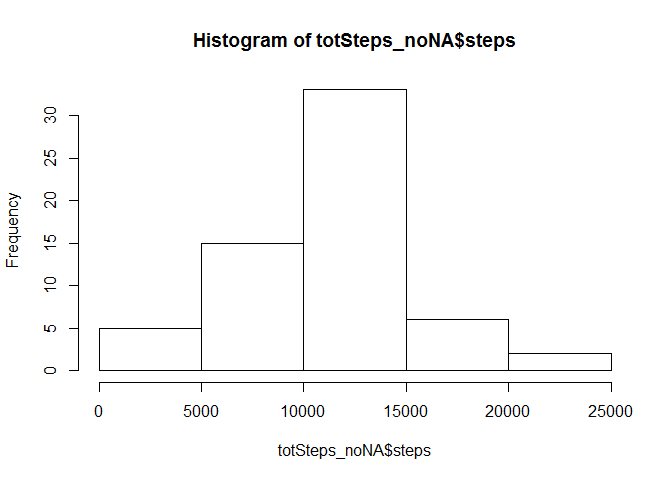

```r
totSteps_noNA <- aggregate(steps ~ date, data = acts_noNA, sum)
hist(totSteps_noNA$steps)
```

### Calculating mean of the total number of steps taken per day

```r
mean(totSteps_noNA$steps)
```

```
## [1] 10821.21
```

### Calculating median of the total number of steps taken per day

```r
median(totSteps_noNA$steps)
```

```
## [1] 11015
```

Imputing missing data on the estimates of the total daily number of steps is **making the result different**.

## Are there differences in activity patterns between weekdays and weekends?

### Creating a new factor variable in the dataset with two levels - “weekday” and “weekend” indicating whether a given date is a weekday or weekend day

```r
acts_noNA$week_or_weekend <- ifelse(acts_noNA$day_name %in% c("Saturday", "Sunday"), "weekend", "weekday")
```

### Making a panel plot containing a time series plot (i.e. type = “l”) of the 5-minute interval (x-axis) and the average number of steps taken, averaged across all weekday days or weekend days (y-axis).

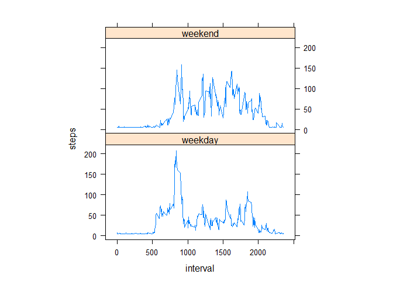

```r
library(lattice)
acts_noNA <- aggregate(steps ~ interval + week_or_weekend, acts_noNA, mean)
xyplot(steps ~ interval | factor(week_or_weekend), data = acts_noNA, aspect = 1/2,
       type = "l")
```